# R Notebook

### Class 1: Exploring the ArcGIS Software Suite

In-class Exercise

- Tools
- Set selectable layers
- Attribute manipulation
- **Deliverable**: exported table

Assignment

- Topology exercise

### Class 2: Displaying Data

In-class Exercise

- Data prep
- Exploring existing ArcMap document
- Exploring ArcMap
- Symbology exercise
- Properties exercise
- Graphs in ArcMap
- **Deliverables**:
  - Exported Symbols .jpeg
  - Exported Propertise .jpeg
  - Exported Graph as .jpeg

Assignment

- Symbology and classigication
- ArcMap practice
- **Deliverable**: Exported map with symbolized data

### Class 3: Information Assessment

- Attribute Query

`r`r VA_counties <- st_read(dsn = 3_data/VA_Counties.shp)

`r`r methods(class = )

[output not shown]

[output cut: 18 more lines]

`r`r head(VA_counties)

```
Simple feature collection with 6 features and 4 fields
geometry type:  MULTIPOLYGON
dimension:      XY
bbox:           xmin: 54807.79 ymin: 289422.6 xmax: 213734.3 ymax: 385298.6
epsg (SRID):    NA
proj4string:    +proj=lcc +lat_1=37 +lat_2=39.5 +lat_0=36 +lon_0=-79.5 +x_0=0 +y_0=0 +datum=NAD83 +units=m +no_defs
  NEWCNTY_ID COUNTY_NAM      ACRES  FIPS                       geometry
1         69  Frederick 265945.294 51069 MULTIPOLYGON (((99210.2 385...
2        107    Loudoun 333411.590 51107 MULTIPOLYGON (((156772.3 37...
3         43     Clarke 114009.066 51043 MULTIPOLYGON (((122759.1 35...
4        840 Winchester   5971.982 51840 MULTIPOLYGON (((112622 3534...
5        171 Shenandoah 327897.692 51171 MULTIPOLYGON (((94332.6 343...
6         59    Fairfax 260177.618 51059 MULTIPOLYGON (((187920.6 34...
```

`r`r ##########################################################

plot(VA_counties[_NAM], reset = FALSE, col = )

plot(VA_counties %>% filter( COUNTY_NAM == ), col = , add = TRUE, reset = FALSE)

```
ignoring all but the first attribute
```

`r`r plot(VA_counties %>% filter( COUNTY_NAM == ), col = , add = TRUE)

```
ignoring all but the first attribute
```

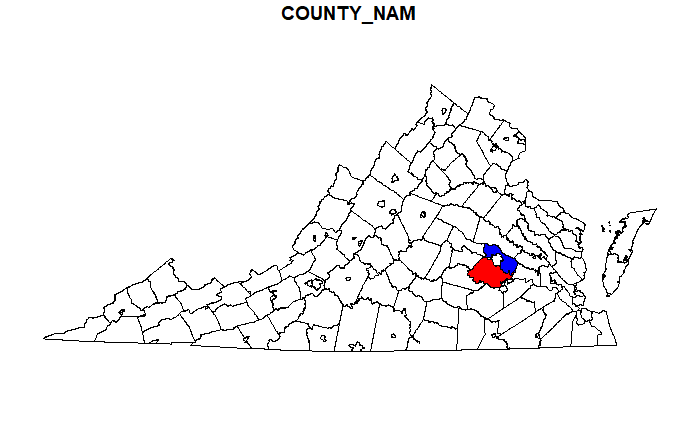

- Spatial Query

How many points fall within Chesterfield County?

`r`r samples <- st_read(dsn = 3_data/strmsamplesite_dd83.shp)

`r`r plot(VA_counties[_NAM], reset = FALSE, col = ) plot(samples[], add = TRUE)

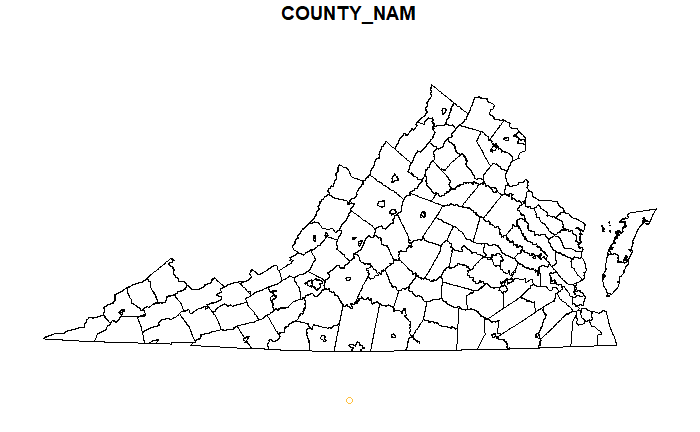

`r`r

# data does not overlay –> check projection (should have done this before anything else)

st_crs(samples)

```
Coordinate Reference System:
  EPSG: 4269
  proj4string: \+proj=longlat +datum=NAD83 +no_defs\
```

`r`r st_crs(VA_counties)

```
Coordinate Reference System:
  No EPSG code
  proj4string: \+proj=lcc +lat_1=37 +lat_2=39.5 +lat_0=36 +lon_0=-79.5 +x_0=0 +y_0=0 +datum=NAD83 +units=m +no_defs\
```

`r`r

# transforming sample site projection to match the county boundaries

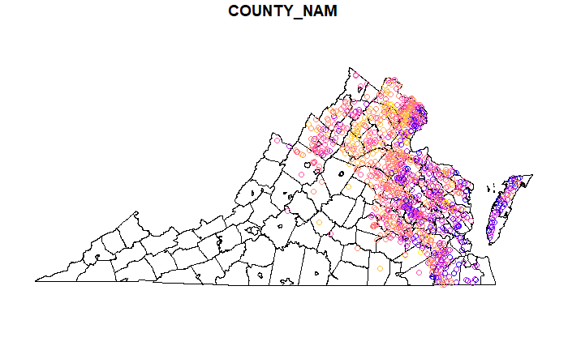

`r`r

# Join the county name column from the VA counties data set to the sample site data set

join <- st_join(samples_proj, counties_proj[_NAM])

```
although coordinates are longitude/latitude, st_intersects assumes that they are planar
although coordinates are longitude/latitude, st_intersects assumes that they are planar
```

`r`r # number of sample sites in Chesterfield –> filter data, count the number of rows

join %>% filter(COUNTY_NAM == ) %>% nrow()

```
[1] 34
```

`r`r # 34 sample sites in Chesterfield

How many roads travel through Chesterfield County?

`r`r

roads <- st_read(dsn = 1_data/vector/VDOT_Main_Roads.shp)

`r`r st_crs(roads)

```
Coordinate Reference System:
  No EPSG code
  proj4string: \+proj=lcc +lat_1=37 +lat_2=39.5 +lat_0=36 +lon_0=-79.5 +x_0=0 +y_0=0 +datum=NAD83 +units=m +no_defs\
```

`r`r head(roads)

```
Simple feature collection with 6 features and 3 fields
geometry type:  LINESTRING
dimension:      XY
bbox:           xmin: 146449.8 ymin: 304052.3 xmax: 150661.3 ymax: 307938.5
epsg (SRID):    NA
proj4string:    +proj=lcc +lat_1=37 +lat_2=39.5 +lat_0=36 +lon_0=-79.5 +x_0=0 +y_0=0 +datum=NAD83 +units=m +no_defs
  ROUTE_NAME ALT_ROUTES ROAD_TYPE                       geometry
1      US 17       <NA>         2 LINESTRING (146618.9 307938...
2      US 15       US29         2 LINESTRING (150661.3 305245...
3      US 15       US29         2 LINESTRING (149838.5 304435...
4      US 15       US29         2 LINESTRING (149684.7 304283...
5      US 15       US29         2 LINESTRING (149590.6 304188...
6 BUS. US 15   BUS.US29         2 LINESTRING (149285.6 304052...
```

`r`r plot(roads_proj[_NAME])

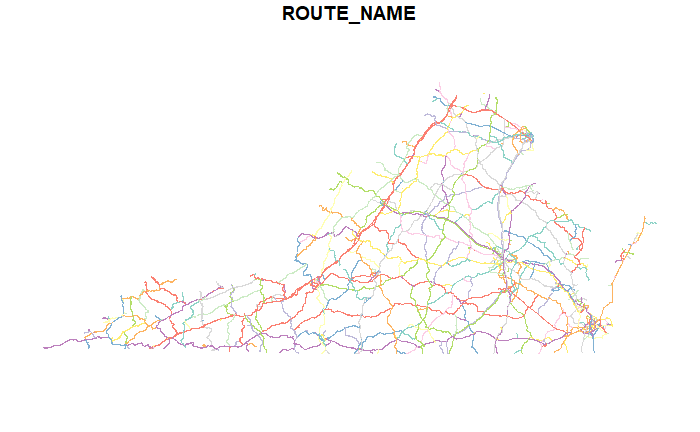

`r`r

roads_join <- st_join(counties_proj, roads_proj[_NAME])

```
although coordinates are longitude/latitude, st_intersects assumes that they are planar
```

`r`r roads_join %>% filter(COUNTY_NAM == ) %>% nrow()

```
[1] 948
```

`r`r #Join the other way

roads_join2 <- st_join(roads_proj, counties_proj[_NAM])

```
although coordinates are longitude/latitude, st_intersects assumes that they are planar
```

`r`r roads_join2 %>% filter(COUNTY_NAM == ) %>% nrow()

```
[1] 948
```

`r`r head(roads_join2)

```
Simple feature collection with 6 features and 4 fields
geometry type:  LINESTRING
dimension:      XY
bbox:           xmin: -77.81482 ymin: 38.72718 xmax: -77.76672 ymax: 38.76263
epsg (SRID):    NA
proj4string:    +proj=longlat +ellps=GRS80 +towgs84=0,0,0,0,0,0,0 +no_defs
  ROUTE_NAME ALT_ROUTES ROAD_TYPE COUNTY_NAM                       geometry
1      US 17       <NA>         2   Fauquier LINESTRING (-77.81265 38.76...
2      US 15       US29         2   Fauquier LINESTRING (-77.76672 38.73...
3      US 15       US29         2   Fauquier LINESTRING (-77.77636 38.73...
4      US 15       US29         2   Fauquier LINESTRING (-77.77816 38.72...
5      US 15       US29         2   Fauquier LINESTRING (-77.77926 38.72...
6 BUS. US 15   BUS.US29         2   Fauquier LINESTRING (-77.7828 38.727...
```

`r`r

roads_Ch2 <- roads_join2 %>% filter(COUNTY_NAM == )

plot(counties_proj[_NAM] %>% filter( COUNTY_NAM == ), col = , reset = FALSE) + plot(roads_Ch2[_NAME], col = , add = TRUE)

```
integer(0)
```

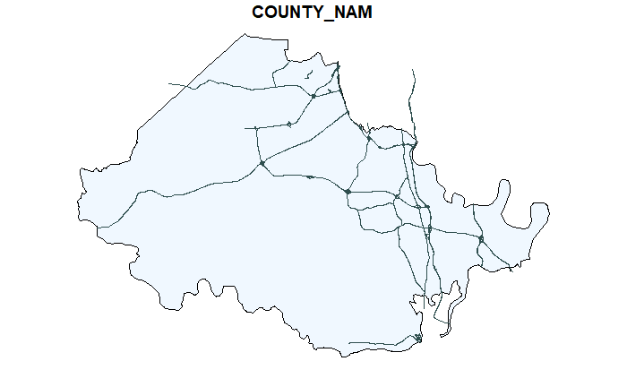

`r`r # Get rid of roads that extend past county boundary

roads_join3 <- st_join(roads_proj, counties_proj[_NAM], join = st_covered_by)

```
although coordinates are longitude/latitude, st_covered_by assumes that they are planar
```

`r`r head(roads_join3)

```
Simple feature collection with 6 features and 4 fields
geometry type:  LINESTRING
dimension:      XY
bbox:           xmin: -77.81482 ymin: 38.72718 xmax: -77.76672 ymax: 38.76263
epsg (SRID):    NA
proj4string:    +proj=longlat +ellps=GRS80 +towgs84=0,0,0,0,0,0,0 +no_defs
  ROUTE_NAME ALT_ROUTES ROAD_TYPE COUNTY_NAM                       geometry
1      US 17       <NA>         2   Fauquier LINESTRING (-77.81265 38.76...
2      US 15       US29         2   Fauquier LINESTRING (-77.76672 38.73...
3      US 15       US29         2   Fauquier LINESTRING (-77.77636 38.73...
4      US 15       US29         2   Fauquier LINESTRING (-77.77816 38.72...
5      US 15       US29         2   Fauquier LINESTRING (-77.77926 38.72...
6 BUS. US 15   BUS.US29         2   Fauquier LINESTRING (-77.7828 38.727...
```

`r`r roads_Ch3 <- roads_join3 %>% filter(COUNTY_NAM == )

plot(counties_proj[_NAM] %>% filter( COUNTY_NAM == ), col = , reset = FALSE) + plot(roads_Ch3[_NAME], col = , add = TRUE)

```
integer(0)
```

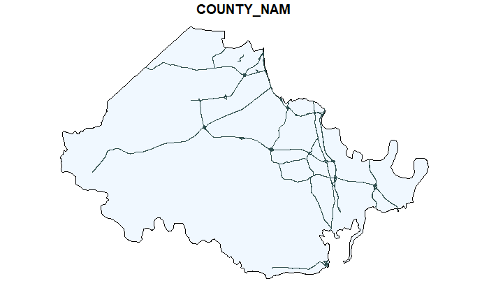

`r`r

roads_join3 %>% filter(COUNTY_NAM == ) %>% nrow()

```
[1] 919
```

In-class Exercise

- Attribute Query

`r`r # Using county data and stream sample sites

head(counties_proj)

```
Simple feature collection with 6 features and 4 fields
geometry type:  MULTIPOLYGON
dimension:      XY
bbox:           xmin: -78.86928 ymin: 38.60472 xmax: -77.0403 ymax: 39.46601
epsg (SRID):    NA
proj4string:    +proj=longlat +ellps=GRS80 +towgs84=0,0,0,0,0,0,0 +no_defs
  NEWCNTY_ID COUNTY_NAM      ACRES  FIPS                       geometry
1         69  Frederick 265945.294 51069 MULTIPOLYGON (((-78.34709 3...
2        107    Loudoun 333411.590 51107 MULTIPOLYGON (((-77.68171 3...
3         43     Clarke 114009.066 51043 MULTIPOLYGON (((-78.07932 3...
4        840 Winchester   5971.982 51840 MULTIPOLYGON (((-78.19646 3...
5        171 Shenandoah 327897.692 51171 MULTIPOLYGON (((-78.40949 3...
6         59    Fairfax 260177.618 51059 MULTIPOLYGON (((-77.3284 39...
```

`r`r head(samples_proj)

```
Simple feature collection with 6 features and 4 fields
geometry type:  POINT
dimension:      XY
bbox:           xmin: -77.82163 ymin: 36.62105 xmax: -76.73862 ymax: 38.70448
epsg (SRID):    NA
proj4string:    +proj=longlat +ellps=GRS80 +towgs84=0,0,0,0,0,0,0 +no_defs
  OBJECTID LOC_CODE      LOC_NAME VSS                   geometry
1        1   E02010 Above Rte 682  71 POINT (-77.82163 38.70448)
2        2   K38007 Below Rte 653  62 POINT (-76.73862 36.62105)
3       41   G05123     Off I-295  67 POINT (-77.43045 37.65275)
4       42   G05126      Off I-95  66 POINT (-77.45054 37.68259)
5       43   G05160      Off I-95  61 POINT (-77.43602 37.66408)
6       44   G05170   Off Rte 301  64 POINT (-77.40815 37.60985)
```

`r`r plot(counties_proj[_NAM], col = , border = 2, reset = FALSE) + plot(samples_proj[], add = TRUE)

```
integer(0)
```

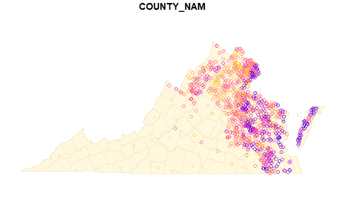

- - How many sample sites have a VSS score greater than 57?

`r`r samples_proj %>% filter(VSS > 57) %>% nrow()

```
[1] 648
```

`r`r #6 48 sample sites have a VSS score greater than 57

- - How many stream sample sites have a VSS score in the 70s?

`r`r samples_proj %>% filter(VSS > 69) %>% filter(VSS < 80) %>% summary()

```
    OBJECTID         LOC_CODE              LOC_NAME        VSS                 geometry
 Min.   :   1.0   A02001 :  1   Above Rte 604  :  2   Min.   :70.00   POINT        :183
 1st Qu.: 320.5   A02004 :  1   Above Rte 659  :  2   1st Qu.:71.00   epsg:NA      :  0
 Median : 463.0   A02006 :  1   Above Rte 660  :  2   Median :73.00   +proj=long...:  0
 Mean   : 677.1   A04004 :  1   Above Rte 688  :  2   Mean   :73.13
 3rd Qu.:1058.5   A05001 :  1   Below Route 654:  2   3rd Qu.:75.00
 Max.   :1809.0   A05003 :  1   Below Rte 601  :  2   Max.   :79.00
                  (Other):177   (Other)        :171
```

`r`r # Use summary to check your work by looking at min and max

# 183 stream sample sites have a VSS score in the 70s

- Location Query
  - How many stream sample sites fall within Hanover County?

`r`r

# Spatial join sample sites to counties

join <- st_join(samples_proj, counties_proj[_NAM])

```
although coordinates are longitude/latitude, st_intersects assumes that they are planar
although coordinates are longitude/latitude, st_intersects assumes that they are planar
```

`r`r # Use filter to just see Hanover

join %>% filter(COUNTY_NAM == ) %>% nrow()

```
[1] 66
```

`r`r # There are 66 sample sites in Hanover County

- Combining Queries
  - How many stream sample site points fall within Accomack County?

`r`r

join %>% filter(COUNTY_NAM == ) %>% nrow()

```
[1] 35
```

`r`r # There are 35 stream sample sites in Accomack County

- - Of those stream sample site points that fall within Accomack, how many have a VSS score greater than 69?

`r`r

join %>% filter(COUNTY_NAM == ) %>% filter(VSS > 69) %>% nrow()

```
[1] 3
```

`r`r # 3 of the stream sample sites in Accomack County have a VSS score greater than 69

- Joining tables
- Join the stream sample sites_Join.dbf to the stream sample site points based off of the Loc_Code field

`r`r

library()

sample_dbf <- read.dbf(3_data/strmsamplesites_Join.dbf)

dbf_join <- merge(samples_proj, sample_dbf, by=_CODE)

- - Symbolize the stream sample site points based on the MIBI scores. Use 5 intervals using natural breaks

`r`r library(RColorBrewer) plot(counties_proj[_NAM], col = 1, border = 4, reset = FALSE) + plot(dbf_join[_SCORE], breaks = , nbreaks= 5, pal = brewer.pal(5,2), pch = 20, add = TRUE)

```
integer(0)
```

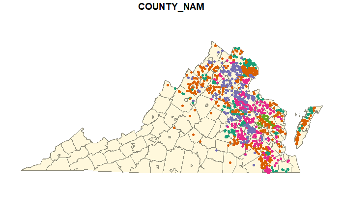

#######################